# Analysing Ultrasound Tongue Imaging data using (M)FPCA and GAMM – Testing with random effects

# 2 What about between-participant variables?

What if we wanted to model the difference between uvular and alveolar rhotics? In the current data set, we have 8 speakers using uvular rhotics and 7 speakers using alveolar rhotics, so this is a between-speaker variable.

The variable `group` describes the rhotic variant, either being *a* for *alveolar* or *u* for *uvular*.

```r
static_items_long <- static_items %>%
  pivot_longer(c(x_mean_z,y_mean_z), names_to = "dimension", values_to = "position") %>%
  mutate(group.dim = paste0(group,".",dimension)) %>%
  mutate(group.dim = factor(group.dim)) %>%
  arrange(clip_id, group.dim, knot) %>% select(-c("x_mean", "y_mean"))
```

The basic univariate GAM should look like this:

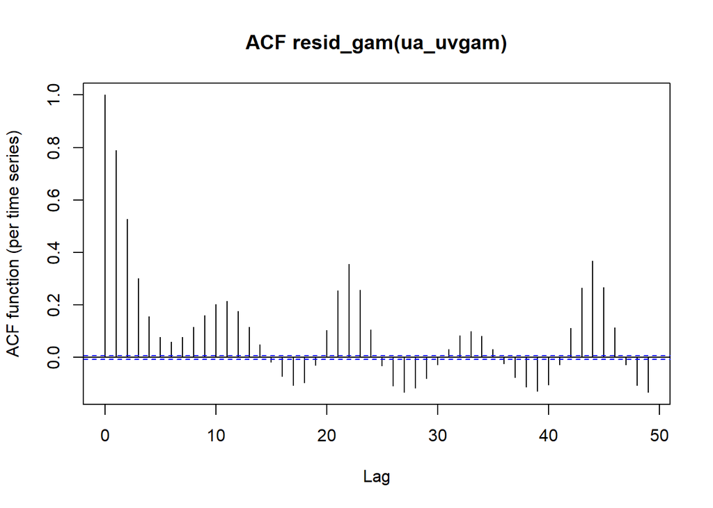

```r
ua_uvgam <- bam(position ~ group.dim +
                  s(knot, by = group.dim),
                    data = static_items_long,
                    family = "scat",
                    discrete = T)
AR1.rho <- acf_resid(ua_uvgam)[2]
```

```r
ua_uvgam <- bam(position ~ group.dim +
                  s(knot, by = group.dim),
                    data = static_items_long,
                    rho = AR1.rho,
                    AR.start = static_items_long %>% pull(knot) == 0,
                    family = "scat",
                    discrete = T)
summary(ua_uvgam)
```

```
Family: Scaled t(6.952,0.132)
Link function: identity

Formula:
position ~ group.dim + s(knot, by = group.dim)

Parametric coefficients:
                      Estimate Std. Error t value Pr(>|t|)
(Intercept)          0.0003521  0.0023287   0.151  0.87983
group.dima.y_mean_z  0.0043511  0.0032933   1.321  0.18643
group.dimu.x_mean_z  0.0031745  0.0032673   0.972  0.33125
group.dimu.y_mean_z -0.0084449  0.0032673  -2.585  0.00975 **
---
Signif. codes:  0 '***' 0.001 '**' 0.01 '*' 0.05 '.' 0.1 ' ' 1

Approximate significance of smooth terms:
                              edf Ref.df     F p-value
s(knot):group.dima.x_mean_z 8.995      9 50123  <2e-16 ***
s(knot):group.dima.y_mean_z 8.995      9 75908  <2e-16 ***
s(knot):group.dimu.x_mean_z 8.996      9 52065  <2e-16 ***
s(knot):group.dimu.y_mean_z 8.997      9 87192  <2e-16 ***
---
Signif. codes:  0 '***' 0.001 '**' 0.01 '*' 0.05 '.' 0.1 ' ' 1

R-sq.(adj) =  0.975   Deviance explained = 90.5%
fREML =  97987  Scale est. = 1         n = 89738
```

Prediction:

```r
ua_uvgam_frame <- expand_grid(
  knot = 0:10,
  group.dim = static_items_long$group.dim %>% levels()
)
```

```r
ua_uvgam_predict <- predict(ua_uvgam, ua_uvgam_frame, se.fit = T) %>%
  as.data.frame() %>% as_tibble() %>%
  bind_cols(ua_uvgam_frame) %>% separate_wider_delim(group.dim, ".", names = c("group", "dimension")) %>%
  pivot_wider(names_from = dimension, values_from = c("fit", "se.fit"))

colnames(ua_uvgam_predict) <- c("knot", "group", "x_mean_z", "y_mean_z", "x_mean_z_se", "y_mean_z_se")
```

```r
ua_uvgam_pred_plot <- ua_uvgam_predict %>% ggplot() +
  aes(x_mean_z, y_mean_z, group = group, color = group) +
  geom_path() + geom_errorbarh(aes(xmin = x_mean_z - 1.96 * x_mean_z_se, xmax = x_mean_z + 1.96 * x_mean_z_se), alpha = 0.5) +
  geom_errorbar(aes(ymin = y_mean_z - 1.96 * y_mean_z_se, ymax = y_mean_z + 1.96 * y_mean_z_se), alpha = 0.5) +
  coord_fixed() +
  theme(legend.position = "bottom")
```

UV-GAM: alveolar vs uvular rhotics

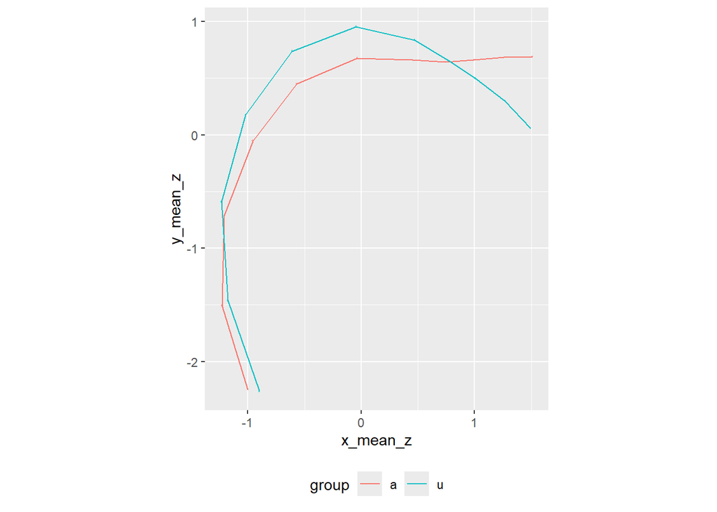

```r
ua_uvgam_pred_plot
```

As expected, we can see a clear difference between these two groups.

## 2.1 add participant as a factor smooth

**Question: What if we wanted to add a factor smooth for participant to this model? Since `group` is not a within-speaker variable, we wouldn’t use it as a `by` variable (comparable to the `language` variable in Coretta and Sakr (2025)), right? What about dimension?**

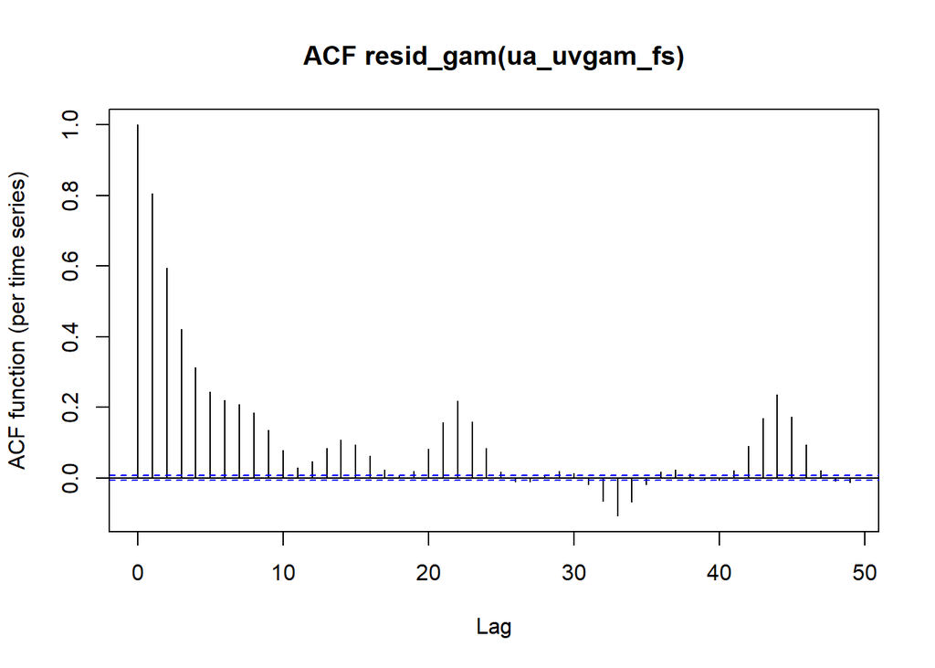

```r
static_items_long$participant <- as.factor(static_items_long$participant)
ua_uvgam_fs <- bam(position ~ group.dim +
                  s(knot, by = group.dim) +
                  s(knot, participant, bs = "fs", m = 1), # factor smooth for participant?
                    data = static_items_long,
                    family = "scat",
                    discrete = T)
AR1.rho <- acf_resid(ua_uvgam_fs)[2]
```

```r
ua_uvgam_fs <- bam(position ~ group.dim +
                  s(knot, by = group.dim) +
                  s(knot, participant, bs = "fs", m = 1), # factor smooth for participant?
                    data = static_items_long,
                    rho = AR1.rho,
                    AR.start = static_items_long %>% pull(knot) == 0,
                    family = "scat",
                    discrete = T)
```

```r
summary(ua_uvgam_fs)
```

```
Family: Scaled t(6.945,0.119)
Link function: identity

Formula:
position ~ group.dim + s(knot, by = group.dim) + s(knot, participant,
    bs = "fs", m = 1)

Parametric coefficients:
                     Estimate Std. Error t value Pr(>|t|)
(Intercept)         -0.002492   0.002492  -1.000   0.3174
group.dima.y_mean_z  0.004921   0.003041   1.618   0.1056
group.dimu.x_mean_z  0.001685   0.003480   0.484   0.6283
group.dimu.y_mean_z -0.007938   0.003480  -2.281   0.0226 *
---
Signif. codes:  0 '***' 0.001 '**' 0.01 '*' 0.05 '.' 0.1 ' ' 1

Approximate significance of smooth terms:
                                edf  Ref.df     F p-value
s(knot):group.dima.x_mean_z   8.757   8.768 146.0 < 2e-16 ***
s(knot):group.dima.y_mean_z   8.757   8.767 114.4 < 2e-16 ***
s(knot):group.dimu.x_mean_z   8.660   8.676 128.1 < 2e-16 ***
s(knot):group.dimu.y_mean_z   8.761   8.773 196.7 < 2e-16 ***
s(knot,participant)         111.719 133.000 443.5 0.00401 **
---
Signif. codes:  0 '***' 0.001 '**' 0.01 '*' 0.05 '.' 0.1 ' ' 1

R-sq.(adj) =   0.98   Deviance explained = 91.2%
fREML =  95483  Scale est. = 1         n = 89738
```

Prediction if we do not remove the random effects:

```r
frame_predict_ua_uv_fs_gam <- expand_grid(
  participant = static_items_long$participant %>% levels(),
  knot = c(0:10),
  dim = c("x_mean_z", "y_mean_z")
) %>% mutate(
  group = case_when(
    participant %in% c("vp004", "vp005", "vp006", "vp007", "vp009", "vp020", "vp038", "vp045") ~ "u",
    participant %in% c("vp008", "vp010", "vp023", "vp040", "vp047", "vp053", "vp056") ~ "a"
  )
) %>% mutate(
  group.dim = paste0(group, ".", dim)
) %>% select(-c("group", "dim"))
```

```r
ua_uv_fs_gam_predict <- predict(ua_uvgam_fs, frame_predict_ua_uv_fs_gam, se.fit = F) %>%
  as.data.frame() %>%
  as_tibble() %>%
  bind_cols(frame_predict_ua_uv_fs_gam) %>%
  separate_wider_delim(group.dim, ".", names = c("group", "dimension")) %>%
  pivot_wider(names_from = dimension, values_from = ".")
```

Plot:

```r
ua_uv_gam_fs_plot <- ggplot(ua_uv_fs_gam_predict) +
  aes(x_mean_z, y_mean_z, group = participant, color = group) +
  geom_path() +
  coord_fixed() +
  facet_wrap(vars(participant), ncol = 5) +
  theme(legend.position = "bottom")
```

UV-GAM: alveolar vs uvular rhotics, factor smooth over knot for participant

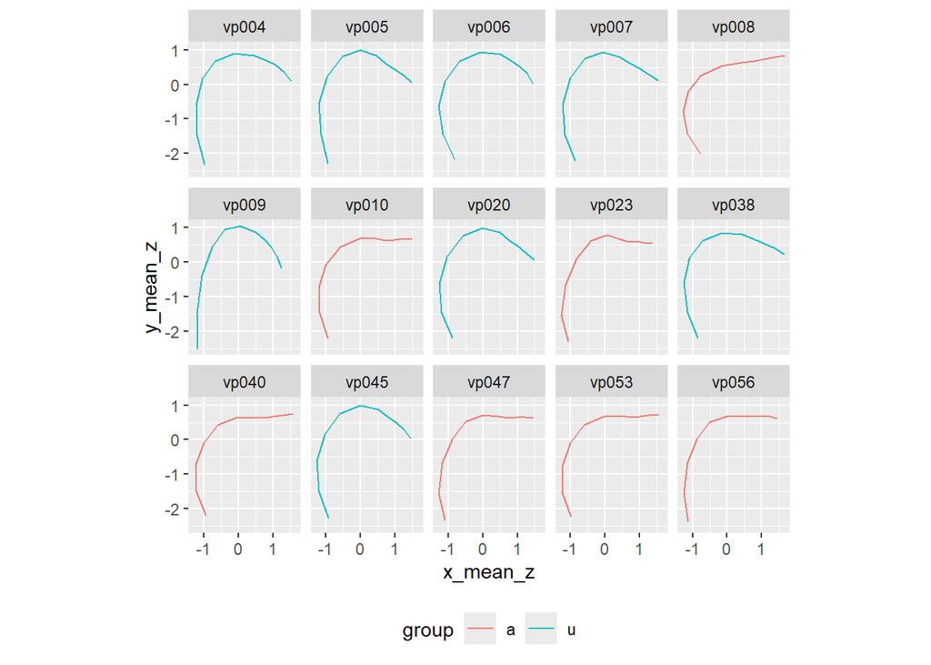

```r
ua_uv_gam_fs_plot
```

If we remove the random effects:

```r
excl <- c("s(knot,participant)")
ua_uv_fs_gam_predict2 <- predict(ua_uvgam_fs, frame_predict_ua_uv_fs_gam, se.fit = F, exclude = excl) %>%
  as.data.frame() %>%
  as_tibble() %>%
  bind_cols(frame_predict_ua_uv_fs_gam) %>%
  separate_wider_delim(group.dim, ".", names = c("group", "dimension")) %>%
  pivot_wider(names_from = dimension, values_from = ".")
ua_uv_fs_pred_plot2 <- ggplot(ua_uv_fs_gam_predict2 %>% subset(participant %in% c("vp004", "vp008"))) +
  aes(x_mean_z, y_mean_z, group = group, color = group) +
  geom_path() +
  coord_fixed() +
  theme(legend.position = "bottom")
```

UV-GAM: alveolar vs uvular rhotics, excluded factor smooth over knot for participant

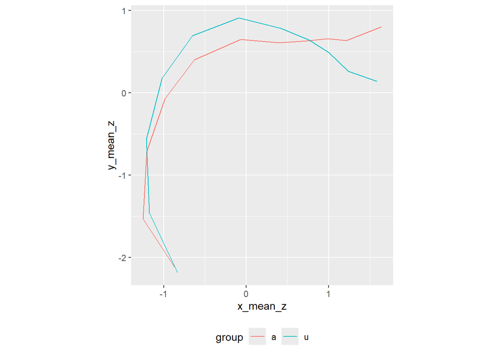

```r
ua_uv_fs_pred_plot2
```

If we add dimension as a `by` variable:

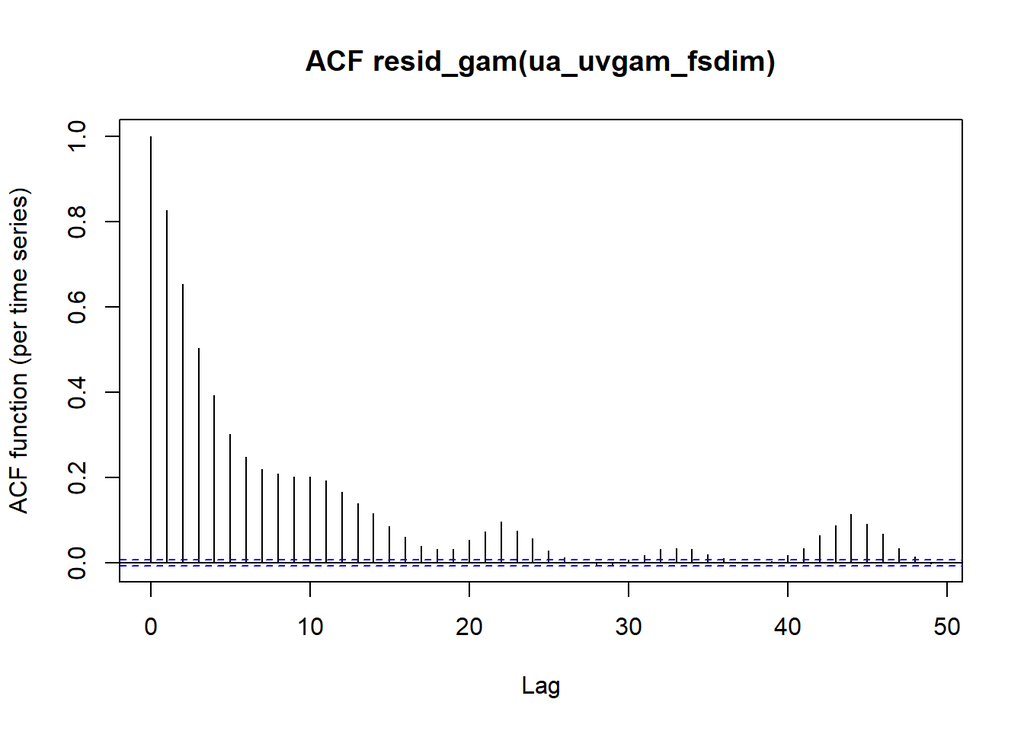

```r
static_items_long$dimension <- as.factor(static_items_long$dimension)
ua_uvgam_fsdim <- bam(position ~ group.dim +
                  s(knot, by = group.dim) +
                  s(knot, participant, by = dimension, bs = "fs", m = 1), # factor smooth for participant?
                    data = static_items_long,
                    family = "scat",
                    discrete = T)
AR1.rho <- acf_resid(ua_uvgam_fsdim)[2]
```

```r
ua_uvgam_fsdim <- bam(position ~ group.dim +
                  s(knot, by = group.dim) +
                  s(knot, participant, by = dimension, bs = "fs", m = 1), # factor smooth for participant?
                    data = static_items_long,
                    rho = AR1.rho,
                    AR.start = static_items_long %>% pull(knot) == 0,
                    family = "scat",
                    discrete = T)
summary(ua_uvgam_fsdim)
```

```
Family: Scaled t(5.805,0.107)
Link function: identity

Formula:
position ~ group.dim + s(knot, by = group.dim) + s(knot, participant,
    by = dimension, bs = "fs", m = 1)

Parametric coefficients:
                     Estimate Std. Error t value Pr(>|t|)
(Intercept)         -0.003839   0.002149  -1.786   0.0740 .
group.dima.y_mean_z  0.003790   0.003697   1.025   0.3053
group.dimu.x_mean_z  0.002955   0.003009   0.982   0.3261
group.dimu.y_mean_z -0.008111   0.003607  -2.249   0.0245 *
---
Signif. codes:  0 '***' 0.001 '**' 0.01 '*' 0.05 '.' 0.1 ' ' 1

Approximate significance of smooth terms:
                                          edf  Ref.df     F  p-value
s(knot):group.dima.x_mean_z             8.556   8.562 201.4  < 2e-16 ***
s(knot):group.dima.y_mean_z             8.109   8.150 133.5  < 2e-16 ***
s(knot):group.dimu.x_mean_z             8.695   8.699 269.2  < 2e-16 ***
s(knot):group.dimu.y_mean_z             8.703   8.718 313.6  < 2e-16 ***
s(knot,participant):dimensionx_mean_z 108.038 133.000 738.2  < 2e-16 ***
s(knot,participant):dimensiony_mean_z 113.557 133.000 734.3 6.71e-05 ***
---
Signif. codes:  0 '***' 0.001 '**' 0.01 '*' 0.05 '.' 0.1 ' ' 1

R-sq.(adj) =  0.983   Deviance explained = 90.7%
fREML =  93638  Scale est. = 1         n = 89738
```

Prediction:

```r
frame_predict_ua_uv_fsdim_gam <- expand_grid(
  participant = static_items_long$participant %>% levels(),
  knot = c(0:10),
  dimension = c("x_mean_z", "y_mean_z")
) %>% mutate(
  group = case_when(
    participant %in% c("vp004", "vp005", "vp006", "vp007", "vp009", "vp020", "vp038", "vp045") ~ "u",
    participant %in% c("vp008", "vp010", "vp023", "vp040", "vp047", "vp053", "vp056") ~ "a"
  )
) %>% mutate(
  group.dim = paste0(group, ".", dimension)
) %>% select(-c("group"))
```

```r
ua_uv_fsdim_gam_predict <- predict(ua_uvgam_fsdim, frame_predict_ua_uv_fsdim_gam, se.fit = F) %>%
  as.data.frame() %>%
  as_tibble() %>%
  bind_cols(frame_predict_ua_uv_fsdim_gam) %>% select(-c("dimension")) %>%
  separate_wider_delim(group.dim, ".", names = c("group", "dimension")) %>%
  pivot_wider(names_from = dimension, values_from = ".")
```

Plot:

```r
ua_uv_gam_fsdim_plot <- ggplot(ua_uv_fsdim_gam_predict) +
  aes(x_mean_z, y_mean_z, group = group, color = group) +
  geom_path() +
  coord_fixed() +
  facet_wrap(vars(participant), ncol = 5) +
  theme(legend.position = "bottom")
```

UV-GAM: alveolar vs uvular rhotics, factor smooth over knot for participant by dimension

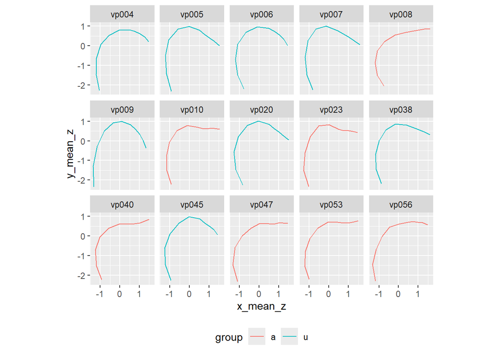

```r
ua_uv_gam_fsdim_plot
```

Exclude factor smooth from prediction:

```r
excl <- c("s(knot,participant):dimensionx_mean_z", "s(knot,participant):dimensiony_mean_z")
```

```r
ua_uv_fsdim_gam_predict2 <- predict(ua_uvgam_fsdim, frame_predict_ua_uv_fsdim_gam, se.fit = F, exclude = excl) %>%
  as.data.frame() %>%
  as_tibble() %>%
  bind_cols(frame_predict_ua_uv_fsdim_gam) %>% select(-c("dimension")) %>%
  separate_wider_delim(group.dim, ".", names = c("group", "dimension")) %>%
  pivot_wider(names_from = dimension, values_from = ".")
```

Plot:

```r
ua_uv_gam_fsdim_plot2 <- ggplot(ua_uv_fsdim_gam_predict2 %>% subset(participant %in% c("vp004", "vp008"))) +
  aes(x_mean_z, y_mean_z, group = group, color = group) +
  geom_path() +
  coord_fixed() +
  theme(legend.position = "bottom")
```

UV-GAM: alveolar vs uvular rhotics, excluded factor smooth over knot for participant by dimension

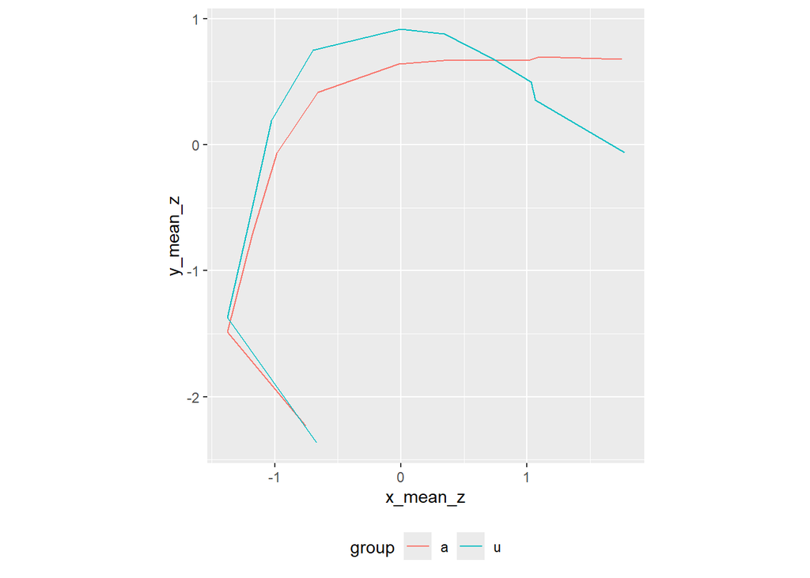

```r
ua_uv_gam_fsdim_plot2
```

Looks very weird! **Question: Why do the predicted splines always look weird when I add `dimension` as a by variable in the factor smooths?**

# 3 Factor Smooths for Dynamic GAMMs?

How do the factor smooths work when we add the time domain?

E.g., we not only want to know if the general tongue position is different between alveolar and uvular rhotics, but also how the tongue movement over time is different.

Dynamic data set:

```r
rhotic_data_dyn <- readRDS("../data/RDS/rhotic_data15.rds") %>% merge(group, by = "participant") %>% plyr::arrange(clip_id,knot)

rhotic_data_dyn_long <- rhotic_data_dyn %>% pivot_longer(c(x_z,y_z), names_to = "dimension", values_to = "position") %>%
  mutate(group.dim = paste0(group,".",dimension)) %>%
  mutate(group.dim = factor(group.dim)) %>%
  arrange(sort_id, group.dim) %>% select(-c("x", "y"))
```

Univariate dynamic GAM:

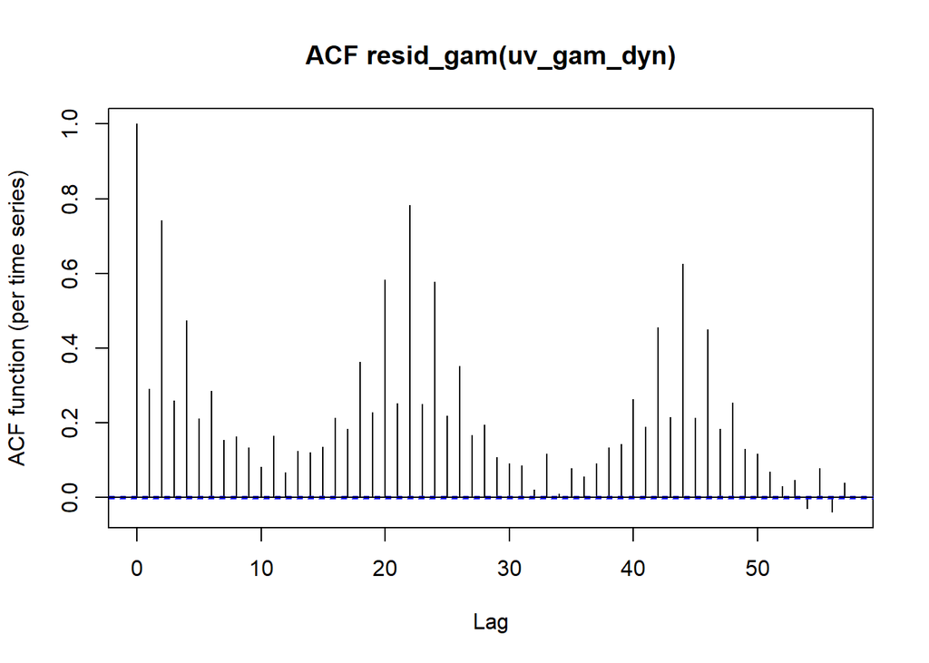

```r
uv_gam_dyn <- bam(position ~ group.dim + te(knot, normtime, by = group.dim),
           data = rhotic_data_dyn_long,
           family = 'scat',
           discrete = T)
AR1.rho <- acf_resid(uv_gam_dyn)[2]
```

```r
uv_gam_dyn <- bam(position ~ group.dim + te(knot, normtime, by = group.dim),
           data = rhotic_data_dyn_long,
           rho = AR1.rho,
            AR.start = rhotic_data_dyn_long %>% pull(knot) == 0,
           family = 'scat',
           discrete = T)
summary(uv_gam_dyn)
```

```
Family: Scaled t(6.604,0.144)
Link function: identity

Formula:
position ~ group.dim + te(knot, normtime, by = group.dim)

Parametric coefficients:
                Estimate Std. Error t value Pr(>|t|)
(Intercept)    0.0021035  0.0005805   3.624  0.00029 ***
group.dima.y_z 0.0243728  0.0005851  41.658  < 2e-16 ***
group.dimu.x_z 0.0018107  0.0007844   2.308  0.02098 *
group.dimu.y_z 0.0136902  0.0007859  17.419  < 2e-16 ***
---
Signif. codes:  0 '***' 0.001 '**' 0.01 '*' 0.05 '.' 0.1 ' ' 1

Approximate significance of smooth terms:
                                   edf Ref.df      F p-value
te(knot,normtime):group.dima.x_z 23.57  23.97 170937  <2e-16 ***
te(knot,normtime):group.dima.y_z 23.68  23.98 174917  <2e-16 ***
te(knot,normtime):group.dimu.x_z 22.71  23.75 191896  <2e-16 ***
te(knot,normtime):group.dimu.y_z 22.51  23.68 198393  <2e-16 ***
---
Signif. codes:  0 '***' 0.001 '**' 0.01 '*' 0.05 '.' 0.1 ' ' 1

R-sq.(adj) =   0.97   Deviance explained = 89.5%
fREML = 7.7924e+05  Scale est. = 1         n = 520124
```

Predict:

```r
uv_gam_dyn_frame <- expand_grid(
  knot = 0:10,
  normtime = (0:5)/5,
  group.dim = rhotic_data_dyn_long$group.dim %>% levels()
)
```

```r
uv_gam_dyn_predict <- predict(uv_gam_dyn, uv_gam_dyn_frame, se.fit = T) %>%
  as.data.frame() %>% as_tibble() %>%
  bind_cols(uv_gam_dyn_frame) %>% separate_wider_delim(group.dim, ".", names = c("group", "dimension")) %>%
  pivot_wider(names_from = dimension, values_from = c("fit", "se.fit"))

colnames(uv_gam_dyn_predict) <- c("knot", "normtime", "group", "x_z", "y_z", "x_z_se", "y_z_se")
```

Plot:

```r
uv_gam_dyn_pred_plot <- uv_gam_dyn_predict %>%
  ggplot(aes(x_z, y_z, colour = normtime, group = normtime)) +
  geom_path() +
  geom_point(size = 0.5, alpha = 0.75) +
  coord_fixed() +
  facet_wrap(vars(group)) +
  theme(legend.position = "bottom")
```

Dynamic UV-GAM: alveolar vs uvular rhotics

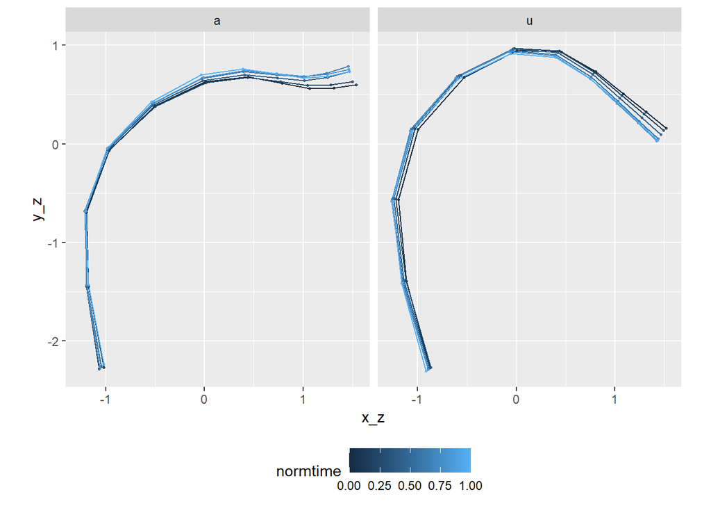

```r
uv_gam_dyn_pred_plot
```

Tongue movement for uvular rhotics goes downwards, for alveolar rhotics it goes upwards.

What if we now wanted to add a factor smooth for participant? What would the term look like?

Here, I included the term `s(knot, participant, bs = "fs", m = 1)` that was also used for the static data. **The variation over time is missing - how would that be included in a fs term?**

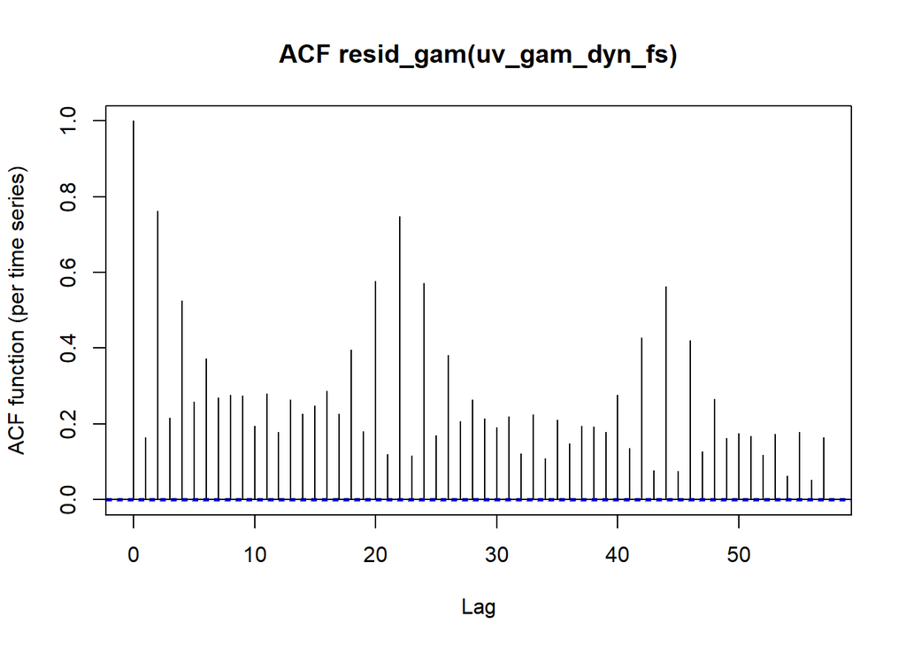

```r
rhotic_data_dyn_long$participant <- as.factor(rhotic_data_dyn_long$participant)
uv_gam_dyn_fs <- bam(position ~ group.dim +
                       te(knot, normtime, by = group.dim) +
                       s(knot, participant, bs = "fs", m = 1), # factor smooth without by-variable
           data = rhotic_data_dyn_long,
           family = 'scat',
           discrete = T)
AR1.rho <- acf_resid(uv_gam_dyn_fs)[2]
```

```r
uv_gam_dyn_fs <- bam(position ~ group.dim +
                       te(knot, normtime, by = group.dim) +
                       s(knot, participant, bs = "fs", m = 1),
           data = rhotic_data_dyn_long,
           rho = AR1.rho,
            AR.start = rhotic_data_dyn_long %>% pull(knot) == 0,
           family = 'scat',
           discrete = T)
summary(uv_gam_dyn_fs)
```

```
Family: Scaled t(6.389,0.132)
Link function: identity

Formula:
position ~ group.dim + te(knot, normtime, by = group.dim) + s(knot,
    participant, bs = "fs", m = 1)

Parametric coefficients:
                Estimate Std. Error t value Pr(>|t|)
(Intercept)    0.0110276  0.0018299   6.027 1.68e-09 ***
group.dima.y_z 0.0210397  0.0006065  34.693  < 2e-16 ***
group.dimu.x_z 0.0005976  0.0025050   0.239  0.81144
group.dimu.y_z 0.0073088  0.0025053   2.917  0.00353 **
---
Signif. codes:  0 '***' 0.001 '**' 0.01 '*' 0.05 '.' 0.1 ' ' 1

Approximate significance of smooth terms:
                                    edf Ref.df      F p-value
te(knot,normtime):group.dima.x_z  23.04  23.86  665.7  <2e-16 ***
te(knot,normtime):group.dima.y_z  20.40  21.10  378.6  <2e-16 ***
te(knot,normtime):group.dimu.x_z  22.31  23.54  179.2  <2e-16 ***
te(knot,normtime):group.dimu.y_z  22.17  23.27  201.5  <2e-16 ***
s(knot,participant)              130.56 134.00 2501.3  <2e-16 ***
---
Signif. codes:  0 '***' 0.001 '**' 0.01 '*' 0.05 '.' 0.1 ' ' 1

R-sq.(adj) =  0.975   Deviance explained =   90%
fREML = 7.9654e+05  Scale est. = 1         n = 520124
```

Predict:

```r
frame_predict_uv_fs_gam_dyn <- expand_grid(
  participant = rhotic_data_dyn_long$participant %>% levels(),
  normtime = c(0:5)/5,
  knot = c(0:10),
  dim = c("x_z", "y_z")
) %>% mutate(
  group = case_when(
    participant %in% c("vp004", "vp005", "vp006", "vp007", "vp009", "vp020", "vp038", "vp045") ~ "u",
    participant %in% c("vp008", "vp010", "vp023", "vp040", "vp047", "vp053", "vp056") ~ "a"
  )
) %>% mutate(
  group.dim = paste0(group, ".", dim)
) %>% select(-c("group", "dim"))
```

```r
uv_gam_dyn_fs_predict <- predict(uv_gam_dyn_fs, frame_predict_uv_fs_gam_dyn, se.fit = F) %>%
  as.data.frame() %>%
  as_tibble() %>%
  bind_cols(frame_predict_uv_fs_gam_dyn) %>%
  separate_wider_delim(group.dim, ".", names = c("group", "dimension")) %>%
  pivot_wider(names_from = dimension, values_from = ".")
```

Plot:

```r
uv_gam_dyn_fs_plot <- ggplot(uv_gam_dyn_fs_predict) +
  aes(x_z, y_z, group = normtime, color = normtime) +
  geom_path() +
  coord_fixed() +
  facet_wrap(vars(participant), ncol = 5) +
  theme(legend.position = "bottom")
```

Dynamic UV-GAM: alveolar vs uvular rhotics, factor smooth over knot for participant

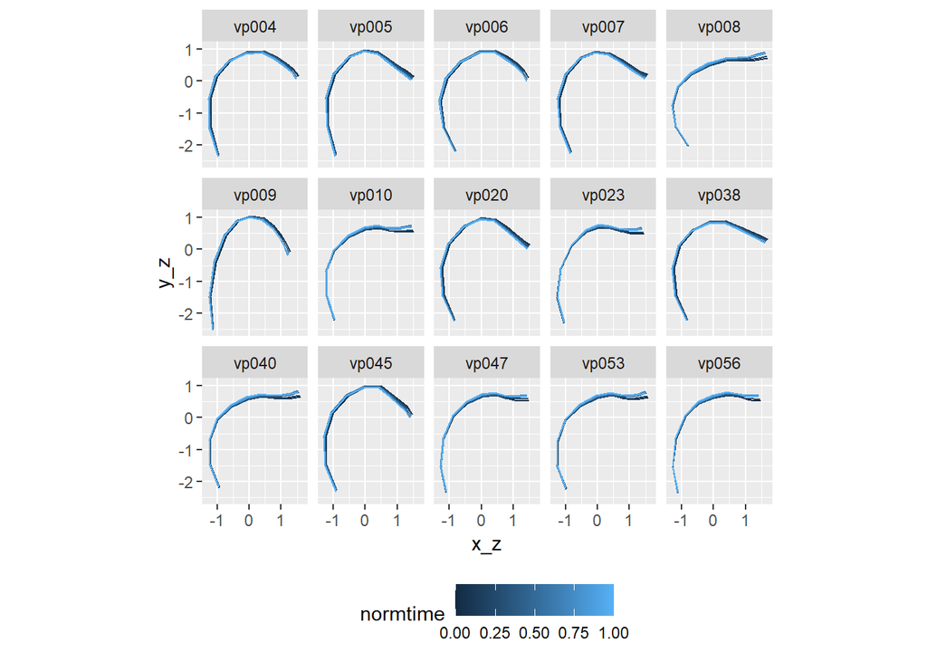

```r
uv_gam_dyn_fs_plot
```

When we exclude the random effects:

```r
excl <- c("s(knot,participant)")
uv_gam_dyn_fs_predict2 <- predict(uv_gam_dyn_fs, frame_predict_uv_fs_gam_dyn, se.fit = F, exclude = excl) %>%
  as.data.frame() %>%
  as_tibble() %>%
  bind_cols(frame_predict_uv_fs_gam_dyn) %>%
  separate_wider_delim(group.dim, ".", names = c("group", "dimension")) %>%
  pivot_wider(names_from = dimension, values_from = ".")
```

```r
uv_gam_dyn_fs_plot2 <- ggplot(uv_gam_dyn_fs_predict2 %>% subset(participant %in% c("vp004", "vp008"))) +
  aes(x_z, y_z, group = normtime, color = normtime) +
  geom_path() +
  coord_fixed() +
  facet_grid(~group) +
  theme(legend.position = "bottom")
```

Dynamic UV-GAM: alveolar vs uvular rhotics, excluded factor smooth over knot for participant

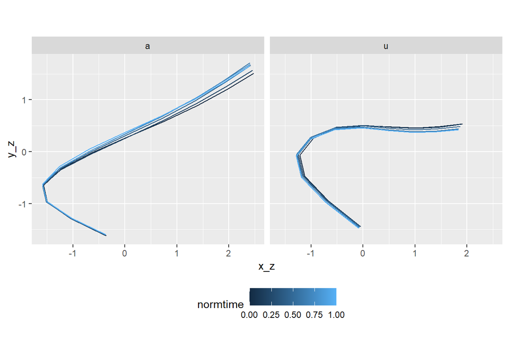

```r
uv_gam_dyn_fs_plot2
```

Well, I guess this didn’t work at all :D

**Question: What factor smooth term would be suitable for this kind of data instead?**

I also tried the same thing with a multivariate dynamic GAMM, but it didn’t work either with the factor smooths.

## References

Coretta, Stefano, and Georges Sakr. 2025. “Stefanocoretta/Mv_uti: V1.1.” Zenodo. https://doi.org/10.5281/zenodo.15335918.

Gubian, Michele. 2025. “Analysis of Uni- and Multi-Dimensional Contours with GAMs and Functional PCA: An Application to Ultrasound Tongue Imaging.” https://github.com/uasolo/FPCA-phonetics-workshop/blob/master/presentations/UTI/UTI_analysis_code.html.